# 16. час: Утврђивање градива

Сада ћемо мало застати и осврнути се на материјал са последња два часа.

**Задатак 1.** Погледај програм и дијаграм, па одговори на следећа питања:

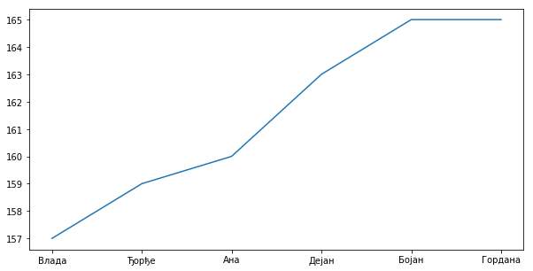

```python
import pandas as pd
import matplotlib.pyplot as plt

podaci = [["Ана",     "ж", 13, 46, 160],
          ["Бојан",   "м", 14, 52, 165],
          ["Влада",   "м", 13, 47, 157],
          ["Гордана", "ж", 15, 54, 165],
          ["Дејан",   "м", 15, 56, 163],
          ["Ђорђе",   "м", 13, 45, 159]]

tabela = pd.DataFrame(podaci)
tabela.columns=["Име", "Пол", "Старост", "Тежина", "Висина"]
tabela1=tabela.set_index("Име")

tabela_po_visini = tabela1.sort_values(by="Висина")

plt.figure(figsize=(10,5))
plt.plot(tabela_po_visini.index, tabela_po_visini["Висина"])
plt.show()
plt.close()
```

1. Зашто крива на дијаграму расте, када то није случај са подацима у листи `podaci`?
2. Зашто је сегмент дијаграма на самом крају хоризонталан?
3. Шта треба изменити у програму да бисмо добили графикон који опада?

**Задатак 2.** Погледај пажљиво наредбе у следећој ћелији, па одговори на питања:

```python
import pandas as pd
aditivi = pd.read_excel("podaci/Aditivi.xlsx", sheet_name="Адитиви", na_filter=False)
```

1. Шта ће урадити функција `read_excel` ако се уклони аргумент `sheet_name="Адитиви"` (знамо да табела има само један радни лист)?
2. Шта значи аргумент `na_filter=False` функције `read_excel`?

**Задатак 3.** Ученици једног разреда су скакали у даљ. Сваки ученик је скако три пута и резултати су дати у датотеци *SkokUDalj.csv* која се налази у фолдеру *podaci*. Табела има заглавље и састоји се од четири колоне: "Презиме и име", "Скок1", "Скок2" и "Скок3".

*(а)* Учитај датотеку у структуру података *DataFrame*.

*(в)* Издвој из табеле оне редове које садрже ученике који су начинили бар један преступ. Преступ је у табели означен тако што је дужина одговарајућег скока постављена на 0.

**Задатак 4.** У табели `podaci/SO2.xlsx` налазе се резултати мерења концентрације сумпор-диоксида у 2017. години у неким градовима Србије. Табела има четири колоне:

- МернаСтаница = Мерна станица
- СГВ = Средња годишња вредност у микрограмима по кубном метру
- БД125 = Број дана са више од 125 микрограма по кубном метру
- МДВ = Максимална дневна вредност у микрограмима по кубном метру

*(а)* Учитај ову табелу у структуру података *DataFrame*.

*(б)* Сортирај подаке по колони СГВ и приказати вредности у овој колони хистограмом.

**Задатак 5.** У табели `podaci/Cricket.xlsx` се налазе подаци о најбољим играчима крикета. Ова табела има заглавље.

*(а)* Учитај ову табелу у структуру података *DataFrame* и испиши првих неколико редова табеле да видиш како изгледа. Индексирај табелу колоном "Player".

*(б)* Додај табели нову колону "YP" (*Years Played*) и у њу упиши колико година је сваки играч био активан. (За сваког играча од године у колони "To" одузети годину у колони "From").

*(в)* Додај табели нову колону "ARY" (*Average Runs per Year*) и у њу упиши количник бројева из колоне "Runs" и "YP". (ARY = Runs / YP).

*(г)* Сортирај табелу по колони "ARY" од највећих ка најмањим вредностима и прикажи првих 25 редова табеле. У ком веку су били активни скоро сви од ових 25 играча? Шта мислиш зашто?

**Задатак 6.** У наредној ћелији се налазе подаци о неколико ученика. За сваког ученика је наведено његово презиме, име, ЈМБГ, пол, разред који похађа и просек на крају тог разреда:

```python
# изврши ову ћелију
podaci = [
    ["Петровић",  "Петар", "0308003800019", "м", 8, 4.52],
    ["Јаснић",    "Јасна", "1210003805026", "ж", 8, 5.00],
    ["Аничић",    "Аница", "1105004805019", "ж", 7, 4.11],
    ["Веснић",    "Весна", "2901005705011", "ж", 6, 5.00],
    ["Ђорђевић",  "Ђорђе", "1504005700012", "м", 6, 3.12],
    ["Милошев",   "Милош", "1506004400056", "м", 7, 2.51],
    ["Милошев",   "Петар", "1506004400057", "м", 7, 2.48],
    ["Ненадовић", "Ненад", "2109003800046", "м", 8, 3.58],
    ["Ненадовић", "Јасна", "2109003805021", "ж", 8, 4.21]]
```

*(а)* Додај нову ћелију испод ове, па у њој формирај одговарајућу табелу позивом функције *DataFrame*.

*(б)* Прикажи секторским дијаграмом полну структуру ове групе. (Додај нову ћелију испод.)

*(в)* Прикажи секторским дијаграмом старосну структуру ове групе узимајући у обзир разред који је ученик завршио. (Додај нову ћелију испод.)

*(г)* Коју колону је најбоље одабрати као кључ за индексирање ове табеле? У ћелији испод ове направи нову табелу која се добија индексирањем претходне табеле одабраном колоном.

*(д)* Шта мислиш, зашто сваки држављанин наше државе има ЈМБГ?

*(ђ)* Направи нову табелу коју чине само ученици осмог разреда.

*(е)* Направи нову табелу коју чине само врло добри ученици.

*(ж)* Направи нову табелу коју чине само дечаци који нису одлични.

**Задатак 7.** У датотеци *podaci/EUProjPop.xlsx* се налазе подаци о очекиваном броју становника ЕУ до 2080. године. Ова табела има два радна листа: *Baseline* на коме се налазе подаци о очекиваном броју становника, и *Migration* на коме се налазе подаци о очекиваном броју становника у случају повећаног броја миграната у земље Европске уније.

*(а)* Учитај ове табелу са радног листа *Baseline* у структуру података *DataFrame* и прикажи првих неколико редова табеле да разумеш њену структуру.

*(б)* Додај табели нову врсту "EU-UK", па израчунај и у ту врсту упиши укупан очекивани број станвника ЕУ за сваку од наведених година *без становника Велике Британије*.

*(г)* Табелу добијену на овај начин упиши у датотеку *podaci/EU-UK.xlsx*